# Predict Buy Car

Eko Nurfitriyanto

5/4/2021

Prediksi harga beli mobil saat ini

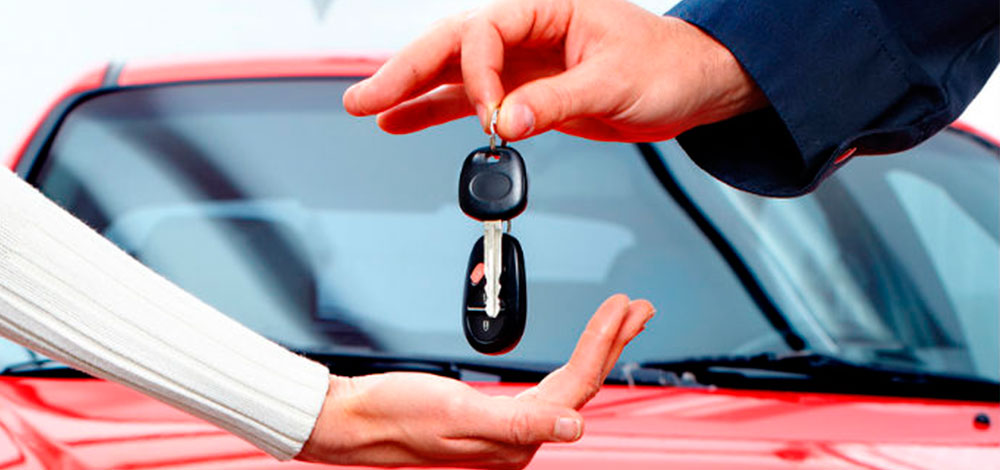

```r
knitr::include_graphics("Beli-mobil.jpg")
```

menggunakan linear regression analysis, akan dibuat suatu model untuk memprediksi faktor-faktor yang menjadikan harga beli mobil

# 1 load dataset

```r
car <- read.csv("data_car.csv")
```

# 2 Explanatory Data Analysis

```r
glimpse(car)
```

```
## Rows: 301
## Columns: 9
## $ Car_Name      <chr> "ritz", "sx4", "ciaz", "wagon r", "swift", "vitara brezz~
## $ Year          <int> 2014, 2013, 2017, 2011, 2014, 2018, 2015, 2015, 2016, 20~
## $ Selling_Price <dbl> 3.35, 4.75, 7.25, 2.85, 4.60, 9.25, 6.75, 6.50, 8.75, 7.~
## $ Present_Price <dbl> 5.59, 9.54, 9.85, 4.15, 6.87, 9.83, 8.12, 8.61, 8.89, 8.~
## $ Kms_Driven    <int> 27000, 43000, 6900, 5200, 42450, 2071, 18796, 33429, 202~
## $ Fuel_Type     <chr> "Petrol", "Diesel", "Petrol", "Petrol", "Diesel", "Diese~
## $ Seller_Type   <chr> "Dealer", "Dealer", "Dealer", "Dealer", "Dealer", "Deale~
## $ Transmission  <chr> "Manual", "Manual", "Manual", "Manual", "Manual", "Manua~
## $ Owner         <int> 0, 0, 0, 0, 0, 0, 0, 0, 0, 0, 0, 0, 0, 0, 0, 0, 0, 0, 0,~
```

Keterangan di setiap kolom:

- `Car_Name`: Nama/model dari mobil
- `Year`: Tahun produksi/pembuatan
- `Selling_Price`: Harga jual mobil
- `Present_Price`: Harga beli mobil saat ini
- `Kms_Driven`: Jumlah kilometer yang sudah ditempuh
- `Fuel_Type`: Jenis bahan bakar
- `Seller_Type`: Jenis penjual
- `Transmission`: Jenis transmisi mobil
- `Owner`: Status sebagai pemilik (1 = yes, 0 = no)

## 2.1 Change data

```r
df_car <- car %>%
  mutate_if(is.character, as.factor)
```

## 2.2 check missing value

cek jumlah missing value (NA) dari tiap kolom

```r
colSums(is.na(df_car))
```

```
##      Car_Name          Year Selling_Price Present_Price    Kms_Driven
##             0             0             0             0             0
##     Fuel_Type   Seller_Type  Transmission         Owner
##             0             0             0             0
```

## 2.3 correlation

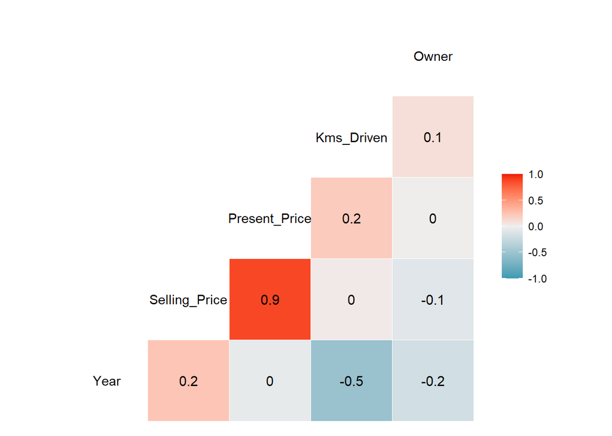

```r
ggcorr(df_car, label = T)
```

Pada grafik korelasi, terlihat bahwa semua variabel memiliki pengaruh positif dan negative terhadap Present_Price dimana faktor Selling_Price memiliki korelasi positif yang paling tinggi dibandingkan faktor-faktor lain.

## 2.4 cek distribusi target variabel (Present Price)

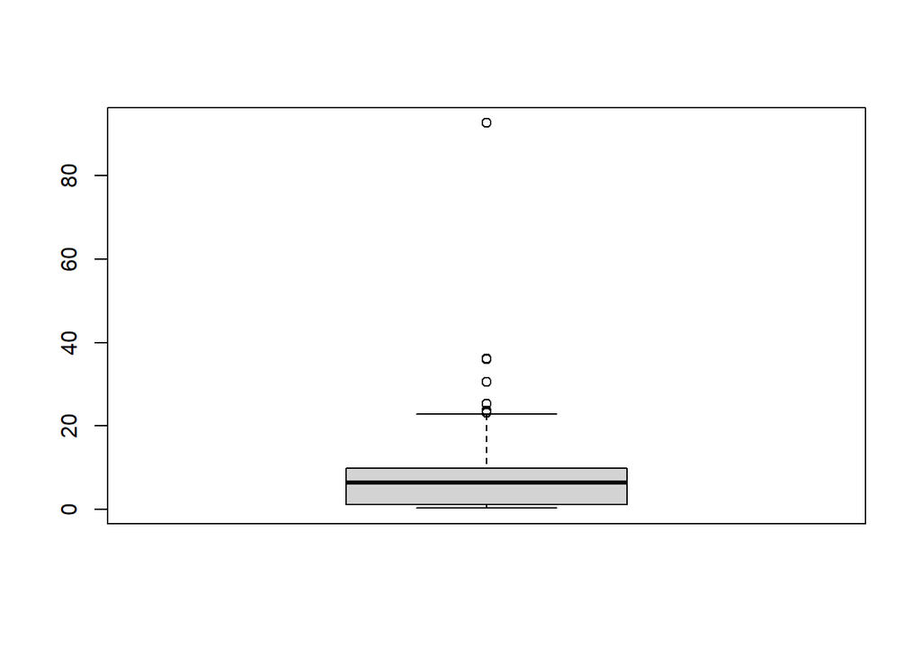

```r
boxplot(df_car$Present_Price)
```

## 2.5 Hubungan tahun dangan present price

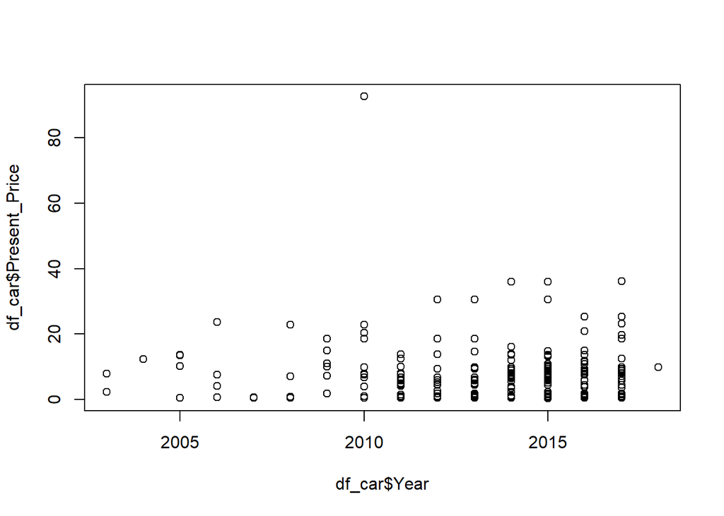

```r
plot(df_car$Year, df_car$Present_Price)
```

## 2.6 rata-rata present price tiap car name

```r
df_car %>%
  group_by(Car_Name) %>%
  summarise(Present_Price= mean(Present_Price),
            freq = n()) %>%
  arrange(desc(Present_Price))
```

| Car_Name | Present_Price | freq |
| --- | --- | --- |
| land cruiser | 92.600000 | 1 |
| fortuner | 30.732727 | 11 |
| camry | 23.730000 | 1 |
| innova | 17.846667 | 9 |
| corolla altis | 17.582500 | 16 |
| elantra | 14.790000 | 2 |
| creta | 13.600000 | 3 |
| corolla | 12.350000 | 1 |
| city | 11.791923 | 26 |
| vitara brezza | 9.830000 | 1 |

[output cut: 88 more lines]

untuk harga termahal jenis mobil land cruiser dan mobil paling banyak yang beli jenis city

# 3 Pembuatan Model Regresi Linear

Selanjutnya dapat dibuat model regresi linear dengan menggunakan model penuh, terhadap variabel target present price dan mem filter nama dari mobil

```r
model_car <-  lm(formula = Present_Price ~ ., data = df_car %>%  select(-Car_Name))
summary(model_car)
```

```
##
## Call:
## lm(formula = Present_Price ~ ., data = df_car %>% select(-Car_Name))
##
## Residuals:
##     Min      1Q  Median      3Q     Max
## -13.990  -1.473   0.124   1.107  32.908
##
## Coefficients:
##                         Estimate Std. Error t value Pr(>|t|)
## (Intercept)            1.403e+03  1.716e+02   8.176 9.07e-15 ***
## Year                  -6.969e-01  8.521e-02  -8.179 8.89e-15 ***
## Selling_Price          1.645e+00  6.015e-02  27.355  < 2e-16 ***
## Kms_Driven             1.335e-05  6.267e-06   2.130    0.034 *
## Fuel_TypeDiesel       -1.772e+00  2.493e+00  -0.711    0.478
## Fuel_TypePetrol       -5.780e-01  2.443e+00  -0.237    0.813
## Seller_TypeIndividual -1.417e-01  5.136e-01  -0.276    0.783
## TransmissionManual     3.416e-01  6.567e-01   0.520    0.603
## Owner                  1.551e+00  8.185e-01   1.895    0.059 .
## ---
## Signif. codes:  0 '***' 0.001 '**' 0.01 '*' 0.05 '.' 0.1 ' ' 1
##
## Residual standard error: 3.425 on 292 degrees of freedom
## Multiple R-squared:  0.8472, Adjusted R-squared:  0.843
## F-statistic: 202.4 on 8 and 292 DF,  p-value: < 2.2e-16
```

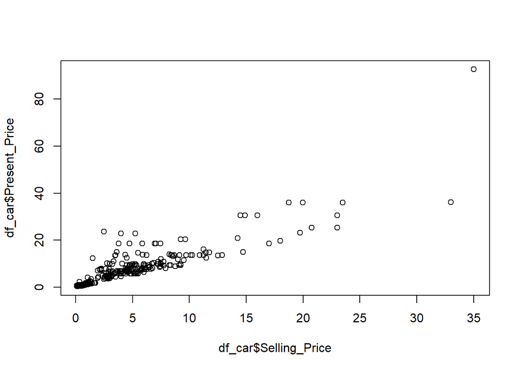

```r
plot(df_car$Selling_Price, df_car$Present_Price)
abline(df_car)
```

## 3.1 model evaluation

prediksi data baru

```r
test_car <- read.csv("car_test.csv")
test_car
```

| Car_Name | Year | Selling_Price | Present_Price | Kms_Driven | Fuel_Type | Seller_Type | Transmission | Owner |
| --- | --- | --- | --- | --- | --- | --- | --- | --- |
| ertiga | 2015 | 7.25 | 10.790 | 41678 | Diesel | Dealer | Manual | 0 |
| ritz | 2012 | 3.10 | 5.980 | 51439 | Diesel | Dealer | Manual | 0 |
| dzire | 2014 | 5.50 | 8.060 | 45000 | Diesel | Dealer | Manual | 0 |
| wagon r | 2006 | 1.05 | 4.150 | 65000 | Petrol | Dealer | Manual | 0 |
| ciaz | 2017 | 7.75 | 9.290 | 37000 | Petrol | Dealer | Automatic | 0 |
| fortuner | 2015 | 23.00 | 30.610 | 40000 | Diesel | Dealer | Automatic | 0 |
| innova | 2017 | 18.00 | 19.770 | 15000 | Diesel | Dealer | Automatic | 0 |
| etios cross | 2015 | 4.50 | 7.270 | 40534 | Petrol | Dealer | Manual | 0 |
| etios g | 2014 | 4.10 | 6.800 | 39485 | Petrol | Dealer | Manual | 1 |
| fortuner | 2014 | 18.75 | 35.960 | 78000 | Diesel | Dealer | Automatic | 0 |

[output cut: 50 more lines]

```r
pred_test <- predict(model_car, newdata = test_car)

head(pred_test)
```

```
##         1         2         3         4         5         6
## 10.063413  5.456176  7.925281  7.639385 10.282011 35.613828
```

Cek Error Model

mean Absolute Error

```r
MAE(pred_test, test_car$Present_Price)
```

```
## [1] 2.591223
```

Mean Absolute precentage Error

```r
MAPE(pred_test, test_car$Present_Price)
```

```
## [1] 1.130904
```

Root Mean Square Error

```r
RMSE(pred_test, test_car$Present_Price)
```

```
## [1] 5.003974
```

# 4 Uji Asumsi

## 4.1 Multikolinearitas

syarat terpenuhin semua variabel VIF < 10, VIF = variance influance factor , ingin cek apakah ada prediktor yang berhubungan dengan prediktor lain.

```r
vif(model_car)
```

```
##                   GVIF Df GVIF^(1/(2*Df))
## Year          1.552555  1        1.246016
## Selling_Price 2.390371  1        1.546083
## Kms_Driven    1.518826  1        1.232407
## Fuel_Type     1.551123  2        1.115993
## Seller_Type   1.544114  1        1.242624
## Transmission  1.275007  1        1.129162
## Owner         1.052988  1        1.026152
```

## 4.2 Error Berdistribusi Normal

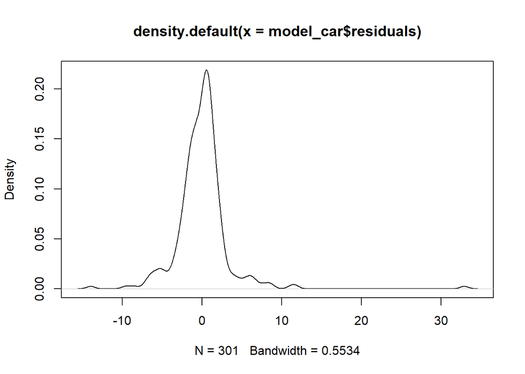

```r
plot(density(model_car$residuals))
```

```r
shapiro.test(model_car$residuals)
```

```
##
##  Shapiro-Wilk normality test
##
## data:  model_car$residuals
## W = 0.76888, p-value < 2.2e-16
```

karena p-value < 0.05, maka residual/error tidak berdistribusi normal

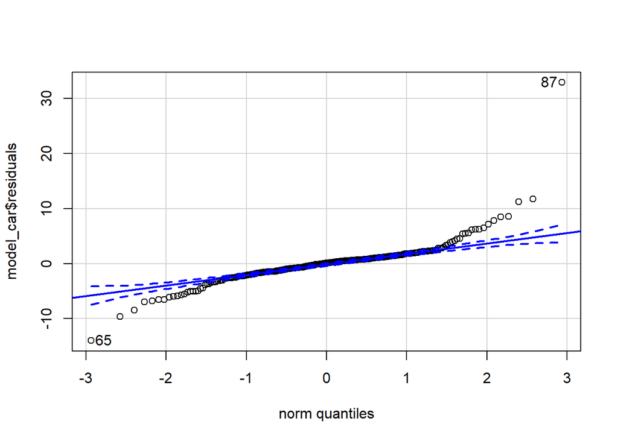

```
## [1] 87 65
```

```r
qqPlot(model_car$residuals)
```

# 5 SHeteroskesdaticity / Unequal Variance

```r
bptest(model_car)
```

```
##
##  studentized Breusch-Pagan test
##
## data:  model_car
## BP = 108.6, df = 8, p-value < 2.2e-16
```

syarat terpenuhi : p-value > 0.05

Dari plot juga terbentuk pola sehingga syarat tidak terpenuhi

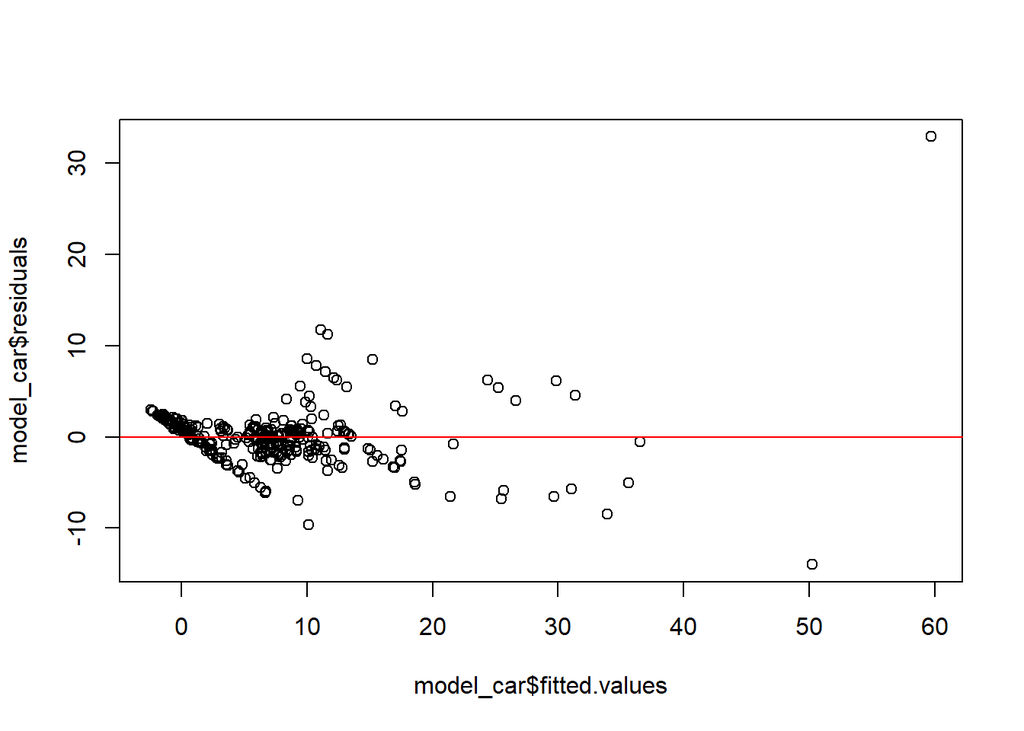

```r
plot(model_car$fitted.values, model_car$residuals)
abline(h = 0, col = "red")
```

## 5.1 Linearity

Dari plot juga terbentuk pola sihingga syarat tidak terpenuhi

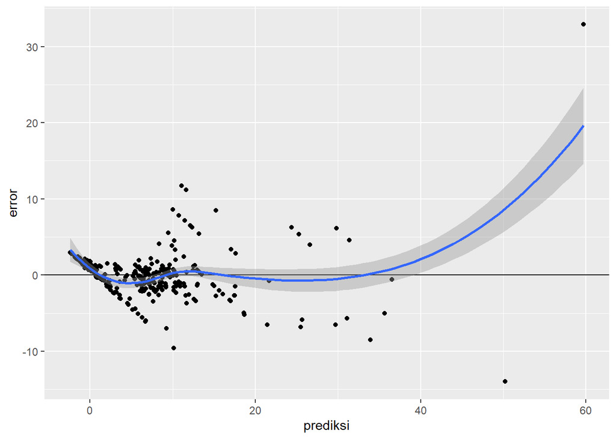

```r
data.frame(prediksi = model_car$fitted.values, error = model_car$residuals) %>%
  ggplot(aes(prediksi,error))+
  geom_hline(yintercept = 0)+ #garis lurus di sumbu y = 0
  geom_point()+
  geom_smooth()
```

# 6 Simpulan dan Saran